# 5.5 Confidence Intervals for a Mean

## Confidence Intervals for a Mean

Realistically, the value of \(\sigma\) is almost never known.

- We know that we can estimate \(\sigma\) using \(s\).
- Can we plug in \(s\) for \(\sigma\)? Sometimes!

## Central Limit Theorem

- For samples of size \(n \ge 30\), \(\bar{X}\) will be approximately normal even if \(X\) isn’t.
- In this case, we can plug in \(s\) for \(\sigma\): \[\bar{x} \pm z_{\alpha/2}\frac{s}{\sqrt{n}}.\]

…but what about when \(n < 30\)?

## The T-Distribution

If \[Z = \frac{\bar{X}-\mu}{\sigma/\sqrt{n}}\] has a standard normal distribution (for \(X\) normal or \(n\ge30\)), the slightly modified \[T = \frac{\bar{X}-\mu}{s/\sqrt{n}}\] has what we call the **t-distribution** with \(n-1\) **degrees of freedom**.

## The T-Distribution

The only thing we need to know about degrees of freedom is that \(\text{df}=n-1\) is the t-distribution’s only parameter.

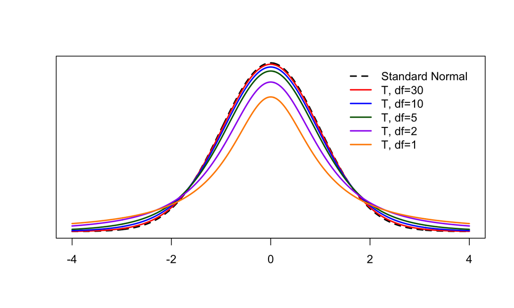

## The T-Distribution

- The t-distribution is symmetric and always centered at 0.
- When \(n\ge30\), the t-distribution is approximately equivalent to the standard normal distribution.
- For smaller sample sizes, the t-distribution has more area in the tails.

## A General Confidence Interval for the Mean

- Plug in \(s\) for \(\sigma\) and use a t critical value \(t_{\text{df}, \, \alpha/2}\).
  - The t critical value is the \([1- \alpha/2]\)th percentile of the t-distribution with \(n-1\) degrees of freedom.
- The resulting 95% confidence interval is \[\bar{x} \pm t_{\text{df}, \, \alpha/2}\frac{s}{\sqrt{n}}.\]

## T-Distribution Applet

[Rossman and Chance t Probability Calculator](http://www.rossmanchance.com/applets/2021/tcalc/tCalc.htm)

- For this applet, enter the degrees of freedom \(n-1\) next to “df”.
- Then check the top box under “t-value probability” and make sure the inequality is clicked to “>” .
- Enter the value of \(\alpha/2\) for the probability.
- Click anywhere else on the page and the applet will automatically fill in the box under “t-value”.
- This is your t critical value.